# Percia_FA6

2024-02-29

## I. Geometric Distribution

Provide an R code for the geometric distribution. The geometric distribution is a probability distribution that models the number of trials required to achieve the first success in a sequence of Bernoulli trials, where each trial has a constant probability of success.

1. Set the probability of success: p <- 0.2
2. Generate 1000 random variables from the geometric distribution.
3. Calculate some basic statistics:
- mean_x <- mean(x)
- var_x <- var(x)
- sd_x <- sd(x)

4.Print the results in item 3 with the following output (string):

- Number of trials required to achieve first success:
- Mean (in 2 decimal places):
- Variance (in 2 decimal places):
- Standard deviation ( in 2 decimal places):
5. Plot the histogram of the results.

```r
## I. Geometric Distribution
# Set the probability of success
p <- 0.2

# Generate 1000 random variables from the geometric distribution
x <- rgeom(1000, p)

# Calculate basic statistics
mean_x <- mean(x)
var_x <- var(x)
sd_x <- sd(x)

# Print the results
cat("Number of trials required to achieve first success:\n")
```

```
## Number of trials required to achieve first success:
```

```r
cat("Mean (in 2 decimal places): ", sprintf("%.2f", mean_x), "\n", sep="")
```

```
## Mean (in 2 decimal places): 3.83
```

```r
cat("Variance (in 2 decimal places): ", sprintf("%.2f", var_x), "\n", sep="")
```

```
## Variance (in 2 decimal places): 17.43
```

```r
cat("Standard deviation (in 2 decimal places): ", sprintf("%.2f", sd_x), "\n", sep="")
```

```
## Standard deviation (in 2 decimal places): 4.17
```

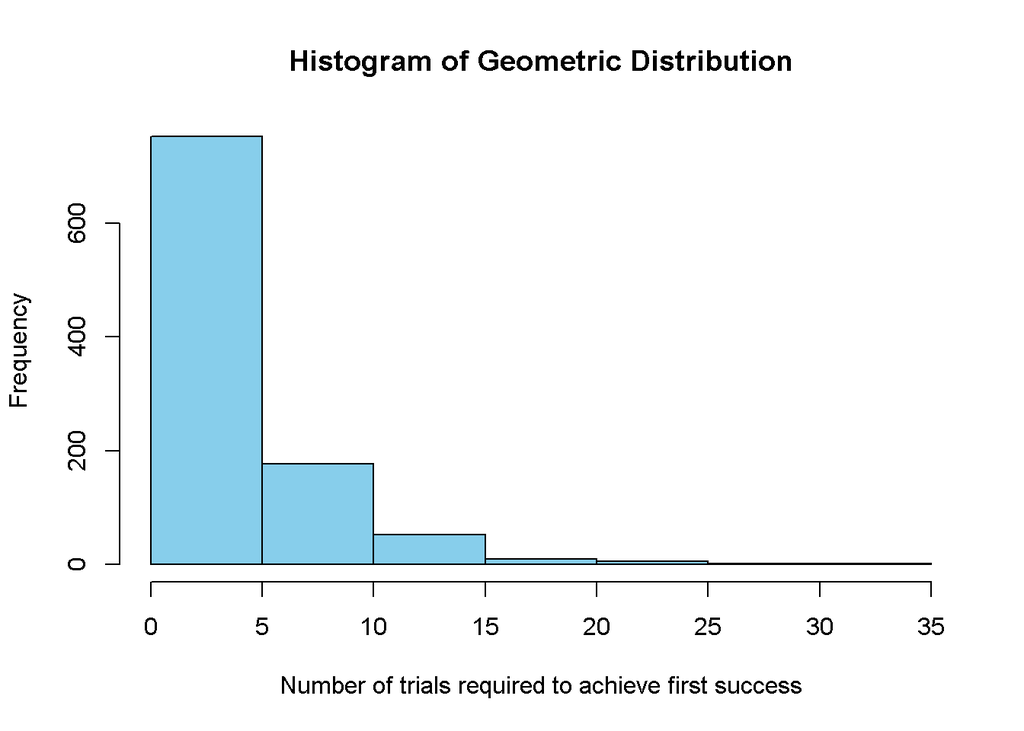

```r
# Plot the histogram
hist(x, main="Histogram of Geometric Distribution", xlab="Number of trials required to achieve first success", ylab="Frequency", col="skyblue")
```